# Practical Machine Learning - Course Project

Tuesday, December 16th 2014

## Exercise Method Classification Using Data from Wearable Devices

## Synopsis

People regularly quantify how much of a particular activity or exercise they do, but they rarely quantify how well they do it. The goal of this project is to use data from accelerometers on the belt, forearm, arm, and dumbell of 6 participants who use wearable devices and predict the manner in which they did the exercise. For more information on this project, please visit http://groupware.les.inf.puc-rio.br/har.

## Data Preprocessing

The training data for this project are available here: https://d396qusza40orc.cloudfront.net/predmachlearn/pml-training.csv. The test data are available here: https://d396qusza40orc.cloudfront.net/predmachlearn/pml-testing.csv

```r
rm (list = ls())
library (caret)
library(rattle)
library (e1071)
library (party)
```

The following steps were taken to preprocess (load and clean) the data:

```r
# Load the datasets
training <- read.csv ("pml-training.csv", na.strings=c("NA","#DIV/0!",""))
testing <- read.csv ("pml-testing.csv", na.strings=c("NA","#DIV/0!",""))

set.seed (101)

# Find predictors with zero variability
nzvTrainSubset <- nearZeroVar(training)
#nPredTrainInitial <- dim (training)

# Remove the near zero variability predictors from the datasets
training <- training [, -nzvTrainSubset]
testing <- testing [, -nzvTrainSubset]

#nPredTrainAfter <- dim (training)
#nPredTestAfter <- dim (testing)

# Count the number of non-NAs in each col.
naCounts <- function(x) {
  as.vector(apply(x, 2, function(x) length(which(is.na(x)))))
}

# Build vector of missing data or NA columns to drop.
colNACounts <- naCounts(training)
drops <- c()
for (cnt in 1:length(colNACounts)) {
  if (colNACounts[cnt] > 0.5 * nrow(training)) {
    drops <- c(drops, colnames(training)[cnt])
  }
}

# Drop the columns that have more than 50% of their values as NA.
training <- training [, !names(training) %in% drops]
testing <- testing [, !names(testing) %in% drops]

# Remove the first 7 columns since they don't add any value to the dataset
training <- training [, 7:length(names(training))]
testing <- testing [, 7:length(names(testing))]

# Partition the training dataset into training and test datasets. 60% of the training data will be used for model training and the other 40% will be used for testing.
# From here onwards, I will refer to this data as the "final prediction dataset" to avoid confusion.
inTrainSubset <- createDataPartition (training$classe, p = 0.6, list = FALSE)
trainSubset <- training[inTrainSubset,]
trainTestSubset <- training [-inTrainSubset, ]

# Final training dataset dimensions
dim (trainSubset)
```

```
## [1] 11776    53
```

## Model

### Classification Tree Model

First I attempted to use a classification tree model using k-fold validation with k = 10. I used k-fold validation throughout this project on the training set whenever possible.

```r
# Define train control method to apply K-Fold validation on the classification models.
train_control <- trainControl(method="cv", number=10)

# Fit the training data to the "Classification Trees" algorithm.
modTreesFit <- train (classe ~ ., method = "rpart",
                      trControl = train_control, data = trainSubset)
predModTreesFit <- predict(modTreesFit, newdata = trainTestSubset)
cfMx <- confusionMatrix(predModTreesFit, trainTestSubset$classe)
accuracy <- round(cfMx$overall["Accuracy"], digits=4) * 100
accuracy
```

```
## Accuracy
##    47.54
```

### Classification Tree Model with Bagging

```r
# Classification Trees with Bagging
modTreeBag <- bag(trainSubset[, -53], trainSubset$classe, B = 10,
                  trControl=train_control,
                  bagControl = bagControl(fit = ctreeBag$fit,
                                          predict = ctreeBag$pred,
                                          aggregate = ctreeBag$aggregate))
predModTreeBag <- predict(modTreeBag, trainTestSubset)
cfMx <- confusionMatrix(predModTreeBag, trainTestSubset$classe)
accuracy <- round(cfMx$overall["Accuracy"], digits=4) * 100
accuracy
```

```
## Accuracy
##    95.73
```

The results of the bagged classification tree model were much better with an accuracy of **95.73%**. Since we know that the random forest algorithm can be very accurate, I used it to create a model as shown below. Note that we do not use cross validation here since the random forest algorithm already has cross validation built into it as described by the authors of the original algorithm here https://www.stat.berkeley.edu/~breiman/RandomForests/cc_home.htm#ooberr. However, we will, of course, validate the model on our test dataset.

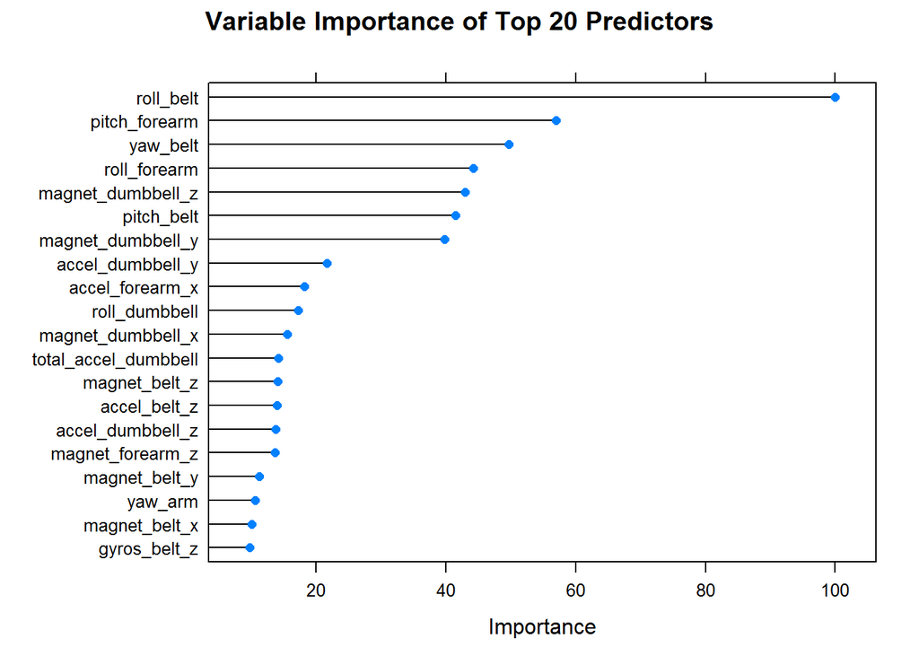

```r
# Random Forests
modFitRF <- train(classe ~ ., method="rf", data=trainSubset, verbose = FALSE)
varImpObj <- varImp(modFitRF)
# Plot the importance of the top 20 predictors.
plot(varImpObj, main = "Variable Importance of Top 20 Predictors", top = 20)
```

```r
# Model Structure
print(modFitRF, digits = 3)
```

```
## Random Forest
##
## 11776 samples
##    52 predictor
##     5 classes: 'A', 'B', 'C', 'D', 'E'
##
## No pre-processing
## Resampling: Bootstrapped (25 reps)
##
## Summary of sample sizes: 11776, 11776, 11776, 11776, 11776, 11776, ...
##
## Resampling results across tuning parameters:
##
##   mtry  Accuracy  Kappa  Accuracy SD  Kappa SD
##    2    0.986     0.982  0.00223      0.00282
##   27    0.987     0.983  0.00254      0.00322
##   52    0.974     0.968  0.00570      0.00723
##
## Accuracy was used to select the optimal model using  the largest value.
## The final value used for the model was mtry = 27.
```

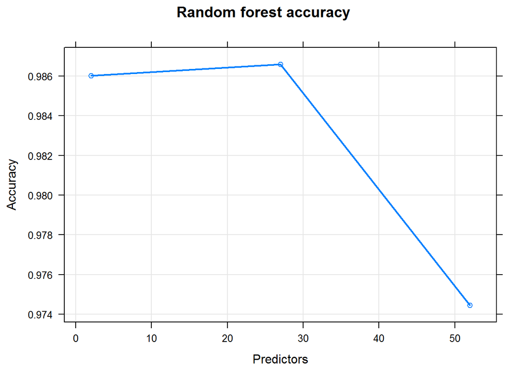

```r
# Plot the accuracy of predictors in the model
plot (modFitRF, log = "y", lwd = 2, main = "Random forest accuracy",
      xlab = "Predictors", ylab = "Accuracy")
```

```r
predModRF <- predict(modFitRF, trainTestSubset)
cfMxRF <- confusionMatrix(predModRF, trainTestSubset$classe)
accuracy <- round(cfMxRF$overall["Accuracy"], digits=4) * 100
accuracy
```

```
## Accuracy
##    98.87
```

### Stacked Model

Technically, at this point, I could have applied the random forest model on the prediction test dataset. However, in an effort to further improve the accuracy, I decided to create a stacked model.

Since boosting and support vector machine algorithms are known for their high accuracy along with random forests, I decided to create models based on these algorithms and then create a stacked model on top of these models.

#### Boosting Model

```r
# Boosting
modFitGBMBoost <- train(classe ~ ., method="gbm", data=trainSubset,
                        trControl = train_control,
                        verbose = FALSE)
predModGBMBoost <- predict(modFitGBMBoost, trainTestSubset)
cfMx <- confusionMatrix(predModGBMBoost, trainTestSubset$classe)
accuracy <- round(cfMx$overall["Accuracy"], digits=4) * 100
accuracy
```

```
## Accuracy
##    95.78
```

The results of the boosting algorithm were better than the bagged classification tree but not better than the random forest. The boosting algorithm resulted in an accuracy of **95.78%**.

#### Support Vector Machine Model

```r
# SVM
svmFit <- train(classe ~ ., preProcess=c("center","scale"),
                   method="svmPoly", data=trainSubset,
                   trControl = train_control,
                   verbose = FALSE)
svmPred <- predict(svmFit, trainTestSubset)
cfMx <- confusionMatrix(svmPred, trainTestSubset$classe)
accuracy <- round(cfMx$overall["Accuracy"], digits=4) * 100
accuracy
```

```
## Accuracy
##     98.9
```

The results of the SVM model were almost exactly the same as the random forest with an accuracy of **98.9%**.

#### Stacked Model

I used the bagged classification tree, boosting, random forest and support vector machine models to create a stacked model. The final stacked model used random forests for stacking as shown below.

```r
# Stacked Model
# Training Predictions
predTrainTreeBag <- predict (modTreeBag, trainSubset)
predTrainBoost <- predict (modFitGBMBoost, trainSubset)
predTrainRF <- predict (modFitRF, trainSubset)
predTrainSVM <- predict (svmFit, trainSubset)

# Stacked Training Dataset
stackedTrainPredData <- data.frame (tree1 = predTrainTreeBag, boost1 = predTrainBoost,
                                    rf1 = predTrainRF, svm1 = predTrainSVM,
                                    classe = trainSubset$classe)

# Stacked Model
modStackedFitRF <- train (classe ~ ., method = "rf", data = stackedTrainPredData)

# Testing Predictions
predTestTreeBag <- predict (modTreeBag, trainTestSubset)
predTestBoost <- predict (modFitGBMBoost, trainTestSubset)
predTestRF <- predict (modFitRF, trainTestSubset)
predTestSVM <- predict (svmFit, trainTestSubset)

# Stacked Testing Dataset
stackedTestPredData <- data.frame (tree1 = predTestTreeBag, boost1 = predTestBoost,
                                   rf1 = predTestRF, svm1 = predTestSVM,
                                   classe = trainTestSubset$classe)

# Stacked Model Testing Predictions
predModStackedRF <- predict (modStackedFitRF, stackedTestPredData)
cfMx <- confusionMatrix(predModStackedRF, trainTestSubset$classe)
accuracy <- round(cfMx$overall["Accuracy"], digits=4) * 100
accuracy
```

```
## Accuracy
##    98.81
```

The stacked model resulted in almost the same accuracy as the random forests i.e. **98.81%**. So we will use the random forests model on the prediction test dataset.

## Out of Sample Error

The out of sample error estimate of the Random Forest model was calculated by using the formula: “1 - (Random Forest Model Accuracy)” = **1.13%**. This means that we should be able to correctly predict the outcome for 19 out of the 20 data points in the final prediction dataset.

## Results

Applying the random forests model on the final prediction dataset, I got the following results.

```r
answers <- predict (modFitRF, testing)
answers
```

```
##  [1] B A B A A E D B A A B C B A E E A B B B
## Levels: A B C D E
```